# Machine Learning

mike horst

September 27, 2015

Machine Learning Project

Loading data with summary information. I am commenting out some of the summary functions to save space on the final HTML.

```r
library(ggplot2); library(caret); library(Hmisc); library(nnet)
setwd("~/statistics/R_machine_learning")
# Reproducable results
set.seed(7158)
#setwd("H:/statistics/R_machine_learning")
training <- read.csv("pml-training.csv")
testing <- read.csv("pml-testing.csv")
#str(training)
#head(training)
#table(training$classe)
```

```r
# Remove columns that only report summary data measures
nas <- colnames(training)[colSums(is.na(training)) == 0]
training <- training[, colnames(training) %in% nas]
nasc <- colnames(training)[colSums(training == "") == 0]
training <- training[, colnames(training) %in% nasc]
```

I then constructed boxplots for each variable relative to the classe variable to look for associations and outliers. I produced some extra plots to look specifically at associaitons with outliers excluded. The plots and code are excluded in the output to meet the 5 plot and text limit.

I found some outliers and elected to eliminate them to enhance predictions.

```r
# Remove outlier observations
training <- training[(training$gyros_dumbbell_x > -50 & training$gyros_dumbbell_y < 20
                      & training$gyros_dumbbell_z < 100 & training$magnet_dumbbell_y > -1000 & training$total_accel_forearm < 90 &
                              training$gyros_forearm_x > -20 & training$gyros_forearm_y < 100 & training$gyros_forearm_z < 100), ]
```

I conducted near zero value assessment and constructed a Spearman correlation matrix to look at associations between variables and with the classes outcome variable. The code are commented out to save space on the HTML output.

```r
# Near zero value assessment
#nzv <- nearZeroVar(training, saveMetrics=TRUE)
#nzv
# Create Spearman correlation matrix
#training$classe.n <- as.numeric(training$classe)
#subtraining <- training[, c(8:59, 61)]
#rcorr(as.matrix(subtraining), type="spearman")
```

Noting that several variables had little or no association with the classe outcome variable, I constructed multinomial logistic regression models with a loop to help narrow the number of relevant predictor variables. The predicted outcome variable was the classe variable with “A” set as the referent outcome.

```r
# Multinomial logistic regression
test3 <- NULL
for(i in 8:59) {
        test <- multinom(classe ~ training[, i], data=training)
        test2 <- exp(coef(test))
        test2 <- data.frame(test2[, 2])
        test2$measure <- colnames(training[i])
        test2$classe <- rownames(test2)
        rownames(test2) <- NULL
        colnames(test2) <- c("rr", "measure", "classe")
        test3 <- rbind(test3, test2)
}
```

The following is a plot of multinomial logistic regression range of relative risks for each variable. Based on these data, I subsetted variables to include only those >= to the 3rd quartile so that I am essentially selecting only those that are most associated with the classe outcome variable.

```r
# Plot of range of regression relative risks
rr.min <- data.frame(tapply(test3$rr, test3$measure, min))
rr.max <- data.frame(tapply(test3$rr, test3$measure, max))
rr.range <- cbind(rr.min, rr.max)
rm(rr.min); rm(rr.max)
rr.range$measure <- rownames(rr.range)
rownames(rr.range) <- NULL
colnames(rr.range) <- c("min", "max", "measure")
rr.range$range <- rr.range$max - rr.range$min
summary(rr.range$range)
```

```
##      Min.   1st Qu.    Median      Mean   3rd Qu.      Max.
## 0.0007969 0.0021710 0.0047610 0.0705000 0.0267900 0.8919000
```

```r
quart3 <- quantile(rr.range$range, probs=0.75)
p <- ggplot(rr.range, aes(measure, range, fill=measure))
bar <- geom_bar(stat = "identity")
title <- ggtitle("Range of RR by Measure")
cf <- coord_flip()
th <- theme(legend.position="none")
line <- geom_hline(yintercept = quart3)
p + bar + title + cf + th + line
```

[figure not shown]

```r
# Subset for variables with highest association
incl.var <- rr.range$measure[rr.range$range >= quart3]
incl.var <- c(incl.var, "classe")
subtraining <- training[, (colnames(training) %in% incl.var)]
```

I first tried some trees and other models, but settled on a random forest model as it was producing the most accurate predictions on the training data set. To get the random forest to run, I needed to further subset the training data set.

```r
# Random forest with a random subset of data so that it will run on a desktop
# And only variables that are associated from bivariate analyses
rfselection <- createDataPartition(y=subtraining$classe, p=0.10, list=FALSE)
subtraining2 <- subtraining[rfselection, ]
modFit <- train(classe ~., data=subtraining2, method="rf", prox=TRUE,
                trControl=trainControl(method="cv", number=10), allowParallel=TRUE)
print(modFit)
```

```
## Random Forest
##
## 1964 samples
##   13 predictor
##    5 classes: 'A', 'B', 'C', 'D', 'E'
##
## No pre-processing
## Resampling: Cross-Validated (10 fold)
## Summary of sample sizes: 1768, 1767, 1766, 1768, 1769, 1767, ...
## Resampling results across tuning parameters:
##
##   mtry  Accuracy   Kappa      Accuracy SD  Kappa SD
##    2    0.7953233  0.7404080  0.03307981   0.04193286
##    7    0.7785483  0.7196748  0.04509813   0.05692247
##   13    0.7597199  0.6958424  0.04774538   0.06020871
##
## Accuracy was used to select the optimal model using  the largest value.
## The final value used for the model was mtry = 2.
```

```r
print(modFit$finalModel)
```

```
##
## Call:
##  randomForest(x = x, y = y, mtry = param$mtry, proximity = TRUE,      allowParallel = TRUE)
##                Type of random forest: classification
##                      Number of trees: 500
## No. of variables tried at each split: 2
##
##         OOB estimate of  error rate: 20.93%
## Confusion matrix:
##     A   B   C   D   E class.error
## A 483  23  27  23   2   0.1344086
## B  45 280  25   9  21   0.2631579
## C  36  17 247  37   6   0.2798834
## D  30   5  24 250  13   0.2236025
## E  10  35  14   9 293   0.1883657
```

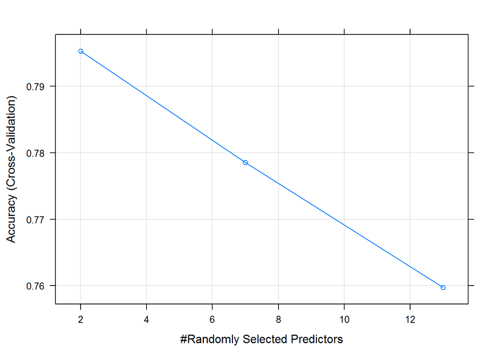

```r
plot(modFit)
```

Here is the assessment of accuracy with the training dataset.

```r
st2validtrain <- subtraining2
st2validtrain$pred1 <- predict(modFit, st2validtrain)
st2validtrain$pred1right <- st2validtrain$pred1 == st2validtrain$classe
confusionMatrix(st2validtrain$pred1, st2validtrain$classe)
```

```
## Confusion Matrix and Statistics
##
##           Reference
## Prediction   A   B   C   D   E
##          A 558   0   0   0   0
##          B   0 380   0   0   0
##          C   0   0 343   0   0
##          D   0   0   0 322   0
##          E   0   0   0   0 361
##
## Overall Statistics
##
##                Accuracy : 1
##                  95% CI : (0.9981, 1)
##     No Information Rate : 0.2841
##     P-Value [Acc > NIR] : < 2.2e-16
##
##                   Kappa : 1
##  Mcnemar's Test P-Value : NA
##
## Statistics by Class:
##
##                      Class: A Class: B Class: C Class: D Class: E
## Sensitivity            1.0000   1.0000   1.0000    1.000   1.0000
## Specificity            1.0000   1.0000   1.0000    1.000   1.0000
## Pos Pred Value         1.0000   1.0000   1.0000    1.000   1.0000
## Neg Pred Value         1.0000   1.0000   1.0000    1.000   1.0000
## Prevalence             0.2841   0.1935   0.1746    0.164   0.1838
## Detection Rate         0.2841   0.1935   0.1746    0.164   0.1838
## Detection Prevalence   0.2841   0.1935   0.1746    0.164   0.1838
## Balanced Accuracy      1.0000   1.0000   1.0000    1.000   1.0000
```

Assessment of importance of variables.

```r
# Calculate importance
importance <- varImp(modFit, scale=FALSE)
# Summarize importance
print(importance)
```

```
## rf variable importance
##
##                      Overall
## pitch_forearm         195.61
## gyros_dumbbell_y      158.17
## gyros_belt_z          144.09
## gyros_arm_y           126.03
## total_accel_dumbbell  121.85
## gyros_dumbbell_x      115.02
## total_accel_arm       108.53
## gyros_forearm_z       107.00
## gyros_forearm_x       103.69
## gyros_arm_z            98.66
## gyros_belt_x           95.92
## gyros_dumbbell_z       91.32
## gyros_belt_y           84.15
```

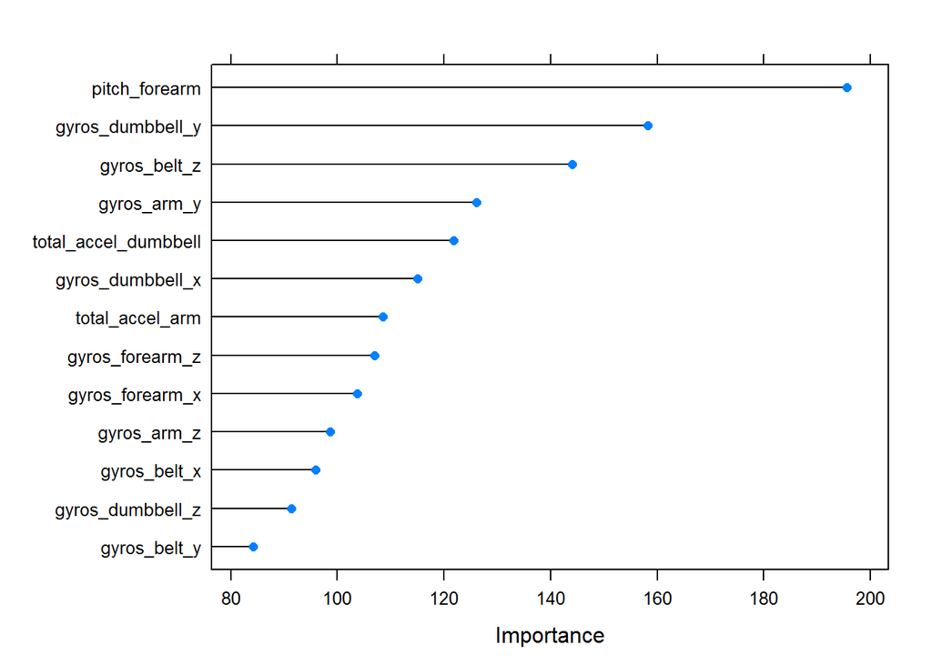

```r
# Plot importance
plot(importance)
```

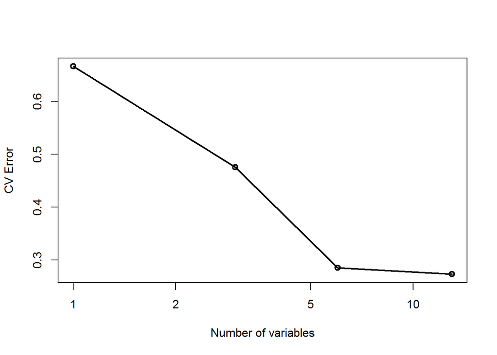

```r
result <- rfcv(trainx = subtraining2[, 1:13], trainy = subtraining2[, 14], ntree = 20)
with(result, plot(n.var,
                  error.cv,
                  log = "x",
                  type = "o",
                  lwd = 2,
                  xlab = "Number of variables",
                  ylab = "CV Error"))
```

Prediction of the testing data.

```r
# Predicting testing data
testing$pred1 <- predict(modFit, testing)
testing$pred1
```

```
##  [1] A A A A A E D C A A A C B A B E A B B B
## Levels: A B C D E
```